# LOOCV

I’m struggloing a bit on how to report the results. In a clinical setting, it would make sense to do a LOOCV, but not necessarily to train the model. Also, a single subject should take away much from finding the initial parameters. So, we could potentially just use the entire dataset to decide on algorithms and pre-processing, and then do a repeated 10fold after LOOCV for each subject.

We’d have to save each model, or just the prediction probabilities, but then it should be easy enough to create the test metrics for the entire dataset.

Let’s see what we can get by doing that. Using AD voxelwise as usual.

```r
myseed=1234
source('~/ncr_notebooks/baseline_prediction/src/aux_functions.R')
tract_data = read.csv('~/data/baseline_prediction/stripped/dti.csv')
load('~/data/baseline_prediction/dti/ad_voxelwise.RData')
dti_vdata = cbind(tract_data$maskid, ad_data)
gf_fname = '~/data/baseline_prediction/stripped/clinical.csv'
gf = read.csv(gf_fname)
gf_base = gf[gf$BASELINE=='BASELINE', ]
my_ids = intersect(gf_base$MRN, tract_data$MRN)
merged = mergeOnClosestDate(gf_base, tract_data, my_ids)
rm_me = abs(merged$dateX.minus.dateY.months) > 12
merged = merged[!rm_me, ]
dti_base_vdata = merge(merged$maskid, dti_vdata, by.x=1, by.y=1, all.y=F, all.x=T)
get_needed_residuals = function(y, fm_str, cutoff, merged) {
  fm = as.formula(fm_str)
  fit = lm(fm)
  # selecting which covariates to use
  fm = "y ~ "
  for (r in 2:dim(summary(fit)$coefficients)[1]) {
    if (summary(fit)$coefficients[r, 4] < cutoff) {
      cname = rownames(summary(fit)$coefficients)[r]
      cname = gsub("SEXMale", "SEX", cname)
      fm = sprintf('%s + %s', fm, cname)
    }
  }
  # don't do anything if no variables were significant
  if (fm == 'y ~ ') {
    return(y)
  } else {
    opt_fit = lm(as.formula(fm))
    return(opt_fit$residuals)
  }
}
X = dti_base_vdata[, 2:ncol(dti_base_vdata)]
rm_me = colSums(is.na(X)) > 0
X = X[, !rm_me]
keep_me = merged$age <= 12
X = X[keep_me, ]
y = merged$DX_BASELINE
y[y!='NV'] = 'ADHD'
y = factor(y, levels=c('ADHD', 'NV'))
y = y[keep_me]
library(parallel)
cl <- makeCluster(6)
X_resid = parSapply(cl, X, get_needed_residuals, 'y ~ merged$age_at_scan + I(merged$age_at_scan^2) + merged$SEX', .1, merged[keep_me, ])
stopCluster(cl)
X_resid = as.data.frame(X_resid)
library(parallel)
cl <- makeCluster(6)
pvals = parSapply(cl, X_resid, function(d, y) t.test(d ~ y)$p.value, y)
stopCluster(cl)
X_resid = X_resid[, which(pvals <= .05)]
print(dim(X_resid))
```

```
[1] 198 953
```

```r
pp <- preProcess(X_resid, method = c('BoxCox', 'center', 'scale', 'pca'), thresh=.9)
filtX<- predict(pp, X_resid)
print(dim(filtX))
```

```
[1] 198 126
```

```r
tuneLength=10
set.seed(myseed)
index <- createMultiFolds(ytrain, k = 10, times = 10)
set.seed(myseed)
fullCtrl <- trainControl(method = "repeatedcv",
                         index = index,
                         savePredictions="final",
                         classProbs=TRUE,
                         summaryFunction=twoClassSummary)
require(doMC)
registerDoMC(cores=6)
library(caretEnsemble)
full_model_list <- caretList(
  filtX, y,
  tuneLength=10,
  trControl=fullCtrl,
  metric='ROC',
  methodList=c('rf', 'kernelpls', 'svmRadial', 'knn', 'rpart', 'bagEarthGCV', 'LogitBoost', 'lda', 'nb')
  )
```

[output not shown]

```r
greedy_ensemble <- caretEnsemble(
  full_model_list,
  metric='ROC',
  trControl=trainControl(
    number=2,
    summaryFunction=twoClassSummary,
    classProbs=TRUE
    ))
# ROC stats
summary(greedy_ensemble)
```

```
The following models were ensembled: rf, kernelpls, svmRadial, knn, rpart, bagEarthGCV, LogitBoost, lda, nb
They were weighted:
-16.1806 1.6622 28.0514 -0.1366 4.6462 -0.8152 0.0727 -0.4813 -0.1255 -0.4858
The resulting ROC is: 0.9882
The fit for each individual model on the ROC is:
      method       ROC      ROCSD
          rf 0.9146316 0.05422694
   kernelpls 0.9885450 0.01869970
   svmRadial 0.9377323 0.05166706
         knn 0.9421248 0.04851733
       rpart 0.7723463 0.09083373
 bagEarthGCV 0.9584925 0.03894912
  LogitBoost 0.8797077 0.07161933
         lda 0.9246332 0.05479254
          nb 0.7702674 0.10195315
```

Using the entire data, it’s clear that PLS is doing the best:

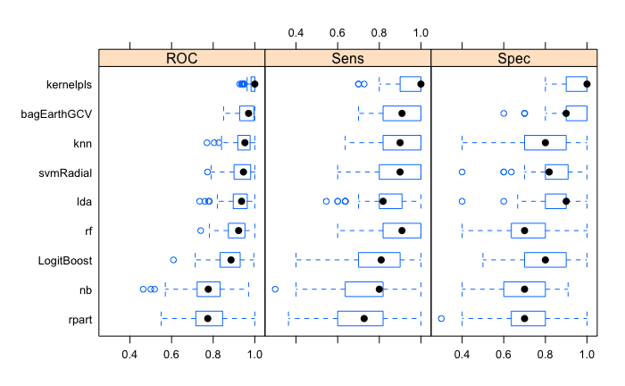

```r
resamps = resamples(full_model_list)
bwplot(resamps, layout = c(3, 1))
```

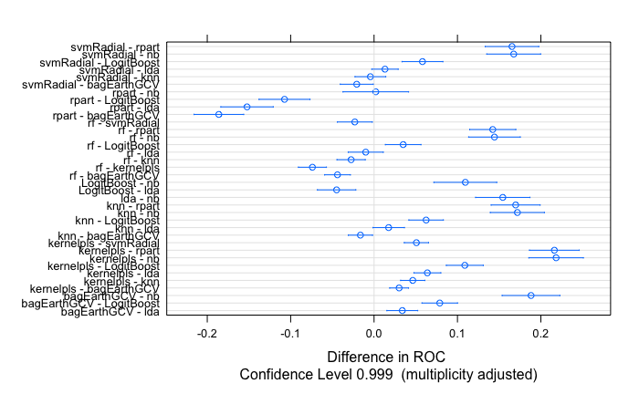

```r
difValues <- diff(resamps)
dotplot(difValues)
```

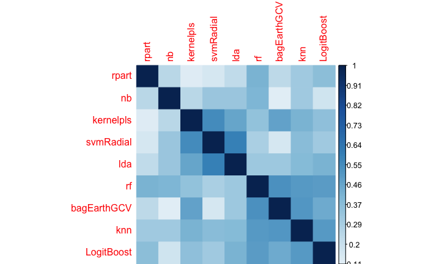

```r
mcor = modelCor(resamps)
library(corrplot)
corrplot(mcor, order = "hclust", method='color', cl.lim=c(min(mcor), max(mcor)))
```

Now, say we do a LOOCV. How well do we predict the left out subject? It also makes sense to use the top 3 models that aren’t too correlated, just so we can have some sort of voting scheme in case the probabilities are too close to call.

```r
myseed=1234
njobs=6
tuneLength=10
preds = c()
for (s in 1:1) {#length(y)) {
  print(sprintf('LO %d / %d', s, length(y)))
  Xtrain <- X_resid[ -s, ]
  ytrain <- y[ -s ]
  Xtest  <- X_resid[s, ]

  library(parallel)
  cl <- makeCluster(njobs)
  pvals = parSapply(cl, Xtrain, function(d, ytrain) t.test(d ~ ytrain)$p.value, ytrain)
  stopCluster(cl)
  Xtrain = Xtrain[, which(pvals <= .05)]
  keep_me = sapply(colnames(Xtrain), function(d) which(colnames(Xtest) == d))
  Xtest = Xtest[, keep_me]

  pp <- preProcess(Xtrain, method = c('BoxCox', 'center', 'scale', 'pca'), thresh=.9)
  filtXtrain<- predict(pp, Xtrain)
  filtXtest <- predict(pp, Xtest)

  set.seed(myseed)
  index <- createMultiFolds(ytrain, k = 10, times = 10)

  set.seed(myseed)
  fullCtrl <- trainControl(method = "boot",
                           index = index,
                           savePredictions="final",
                           classProbs=TRUE,
                           summaryFunction=twoClassSummary)

  require(doMC)
  registerDoMC(cores=njobs)
  library(caretEnsemble)
  model_list <- caretList(
    filtXtrain, ytrain,
    tuneLength=tuneLength,
    trControl=fullCtrl,
    metric='ROC',
    methodList=c('kernelpls', 'bagEarthGCV', 'knn')
  )
  preds = rbind(preds, predict(model_list[[1]], newdata=filtXtest, type='prob'))
}
```

```
[1] "LO 1 / 198"
```

[output not shown]

But this is taking too long. So, lets farm it in a subject level.

```r
preds = c()
preds2 = c()
a = read.table('~/tmp/all_3_varp6.txt')
```

[output not shown]

# Other resampling methods

Let me play with other resampling methods first, using the entire dataset. Ideally we can reduce the variance a bit, even though we’re already quite good with kernelpls. The other idea is to go for maximizing accuracy, as that seems to be a tough thing to sell.

```r
summary(greedy_ensemble)
```

```
The following models were ensembled: rf, kernelpls, svmRadial, knn, rpart, bagEarthGCV, LogitBoost, lda, nb
They were weighted:
-15.0155 -1.7978 28.6262 -0.341 4.0104 -0.1956 -0.6153 0.5241 -0.1752 -0.3088
The resulting Accuracy is: 0.949
The fit for each individual model on the Accuracy is:
      method  Accuracy AccuracySD
          rf 0.8133442 0.07678835
   kernelpls 0.9481061 0.04993326
   svmRadial 0.8659827 0.06304243
         knn 0.8743983 0.07167175
       rpart 0.7529199 0.09107118
 bagEarthGCV 0.9026212 0.05678055
  LogitBoost 0.7986948 0.09288061
         lda 0.8469545 0.06585509
          nb 0.7222554 0.09104425
```

Using the entire data, PLS still does the best:

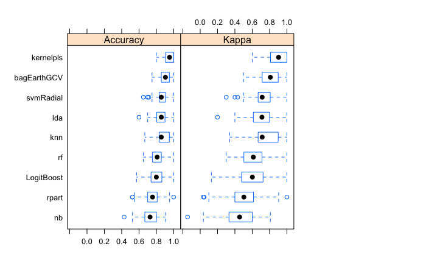

```r
resamps = resamples(full_model_list)
bwplot(resamps, layout = c(3, 1))
```

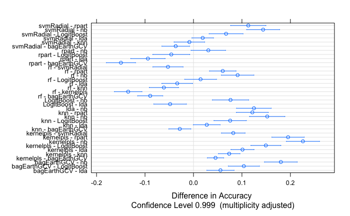

```r
difValues <- diff(resamps)
dotplot(difValues)
```

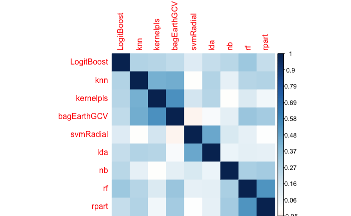

```r
mcor = modelCor(resamps)
library(corrplot)
corrplot(mcor, order = "hclust", method='color', cl.lim=c(min(mcor), max(mcor)))
```

To quickly evaluate the swarmed loocv results:

```r
preds = c()
a = read.table('~/tmp/svmRadial_5pcs.txt')
start=1
while (start <= length(y)) {
  adhd_prob = a[start,2]
  nv_prob = a[start,3]
  if (is.na(adhd_prob) || is.na(nv_prob)) {
    preds = c(preds, 'err')
  } else if (adhd_prob > nv_prob) {
    preds = c(preds, 'ADHD')
  } else {
    preds = c(preds, 'NV')
  }
  start = start+1
}
preds = factor(preds, levels=levels(y))
sum(preds==y)/length(y)
```

```
[1] 0.6262626
```

We are still overfitting with LOOCV… that’s because we only do CV in the training data to select the hyperparameters, but the full model is still fit in the entire dataset (n-1). Even with only 5PCs I’m still overfitting. Tough… will need to play with seed distribution.

But why wouldn’t the results for each fold be worse then?

```r
myseed=1234
source('~/ncr_notebooks/baseline_prediction/src/aux_functions.R')
tract_data = read.csv('~/data/baseline_prediction/stripped/dti.csv')
load('~/data/baseline_prediction/dti/ad_voxelwise.RData')
dti_vdata = cbind(tract_data$maskid, ad_data)
gf_fname = '~/data/baseline_prediction/stripped/clinical.csv'
gf = read.csv(gf_fname)
gf_base = gf[gf$BASELINE=='BASELINE', ]
my_ids = intersect(gf_base$MRN, tract_data$MRN)
merged = mergeOnClosestDate(gf_base, tract_data, my_ids)
rm_me = abs(merged$dateX.minus.dateY.months) > 12
merged = merged[!rm_me, ]
dti_base_vdata = merge(merged$maskid, dti_vdata, by.x=1, by.y=1, all.y=F, all.x=T)
get_needed_residuals = function(y, fm_str, cutoff, merged) {
  fm = as.formula(fm_str)
  fit = lm(fm)
  # selecting which covariates to use
  fm = "y ~ "
  for (r in 2:dim(summary(fit)$coefficients)[1]) {
    if (summary(fit)$coefficients[r, 4] < cutoff) {
      cname = rownames(summary(fit)$coefficients)[r]
      cname = gsub("SEXMale", "SEX", cname)
      fm = sprintf('%s + %s', fm, cname)
    }
  }
  # don't do anything if no variables were significant
  if (fm == 'y ~ ') {
    return(y)
  } else {
    opt_fit = lm(as.formula(fm))
    return(opt_fit$residuals)
  }
}
X = dti_base_vdata[, 2:ncol(dti_base_vdata)]
rm_me = colSums(is.na(X)) > 0
X = X[, !rm_me]
keep_me = merged$age <= 12
X = X[keep_me, ]
y = merged$DX_BASELINE
y[y!='NV'] = 'ADHD'
y = factor(y, levels=c('ADHD', 'NV'))
y = y[keep_me]
X = cbind(merged[keep_me, c('age_at_scan', 'SEX')], X)
# library(parallel)
# cl <- makeCluster(6)
# X_resid = parSapply(cl, X, get_needed_residuals, 'y ~ merged$age_at_scan + I(merged$age_at_scan^2) + merged$SEX', .1, merged[keep_me, ])
# stopCluster(cl)
# X_resid = as.data.frame(X_resid)
```

```r
njobs=6
preds = c()
for (s in 1:198) {
  Xtrain <- X[ -s, ]
  ytrain <- y[ -s ]
  Xtest  <- X[s, ]

  pp <- preProcess(Xtrain, method = c('BoxCox', 'center', 'scale'))
  filtXtrain <- predict(pp, Xtrain)
  filtXtest <- predict(pp, Xtest)

  library(parallel)
  cl <- makeCluster(njobs)
  pvals = parSapply(cl, filtXtrain, function(d, ytrain) kruskal.test(d ~ ytrain)$p.value, ytrain)
  stopCluster(cl)
  filtXtrain = filtXtrain[, which(pvals <= .05)]
  keep_me = sapply(colnames(filtXtrain), function(d) which(colnames(filtXtest) == d))
  filtXtest = filtXtest[, keep_me]

  pp <- preProcess(filtXtrain, method = c('pca'))
  filtXtrain <- predict(pp, filtXtrain)
  filtXtest <- predict(pp, filtXtest)

  tuneLength=10
  set.seed(myseed)
  index <- createResample(ytrain, times=200)

  require(doMC)
  registerDoMC(cores=6)
  set.seed(myseed)
  fullCtrl <- trainControl(method = "boot",
                           number=200,
                           # repeats=10,
                           index = index,
                           savePredictions="all",
                           classProbs=TRUE,
                           returnResamp = 'all',
                           indexFinal=createResample(ytrain, times=1)[[1]])

  require(doMC)
  registerDoMC(cores=njobs)
  set.seed(myseed)
  mymod = train(filtXtrain, ytrain,
                tuneLength=10,
                trControl=fullCtrl,
                metric='Accuracy',
                method='kernelpls')

  print(mymod)
  print(sprintf('LO %d / %d (%s)', s, length(y), y[s]))
  preds = c(preds, predict(mymod, newdata=filtXtest))
  print(preds)
}
```

```r
fitControl <- trainControl(method = "none", classProbs = TRUE)
set.seed(myseed)
nomodel <- train(Xtrain[index[[1]],], ytrain[index[[1]]],
                 method = "kernelpls",
                 trControl = fitControl,
                 verbose = FALSE,
                 tuneGrid = data.frame(ncomp = 3),
                 metric = "Accuracy")
nomodel
```

```
Partial Least Squares

197 samples
956 predictors
  2 classes: 'ADHD', 'NV'

No pre-processing
Resampling: None
```